# Factors that Led to Borrowers Receiving Huge Original Loan Amounts

## by Josephine Seyram Agyeman

## Investigation Overview

In this investigation, I was interested in the variables that would lead to borrowers receiving huge original loan amounts. The main focus was on the number of recommendations the borrowers had and their employment status

## Dataset Overview

The ProsperLoan Dataset contains various variables like term, recommendations, investors, original loan amount, occcupation, among others on approximately 110,000 loan borrowers. Seventy-two variables were dropped from the analysis as they were not important to the main findings in this investigation.

# VISUALIZATIONS

## Distribution of the Loan Original Amounts

The Loan Original Amount given out in the dataset takes on a very large range of values, from 1,000 at the lowest to about 35,000 as the highest. Plotted on a logarithmic scale, the distribution of Loan Orignal Amount takes on a multimodal shape.

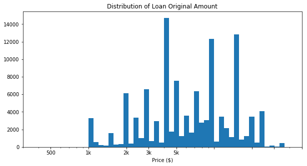

## Distribution of Recommendations

Number of recommendations the borrower had at the time the listing was created. Most of the loans given out had no Recommendations.

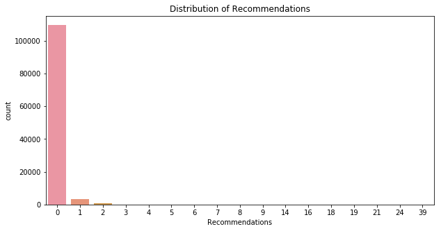

## Distribution of Employment Status

The employment status of the borrower at the time they posted the listing. From the bar plot, most borrowers are employed

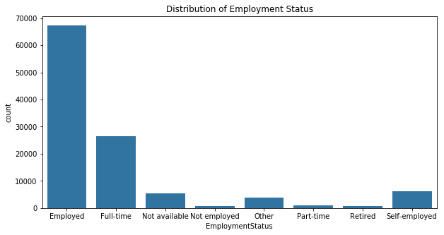

## LoanOriginalAmount vs EmploymentStatus

The Employment Status of borrowers against the loan original amount they received. Those Employed received the largest loan orignal amount which is around $10,000

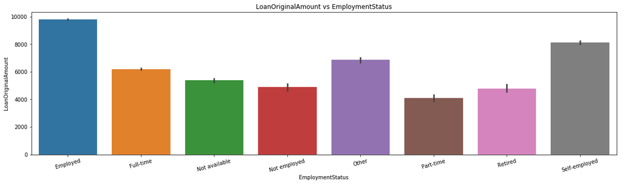

## LoanOriginalAmount vs Recommendations

The average number of Recommendations borrowers had against the average loan original amount they received. The average amounts was used because of the large number of borrowers. Those with 21, 24 and 39 recommendations received more loans which was about $25,000.

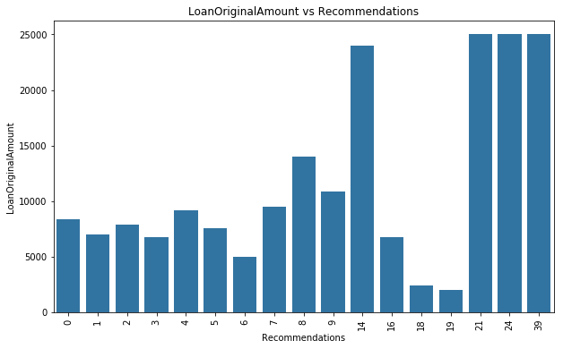

## Term vs LoanOriginalAmount vs LoanStatus

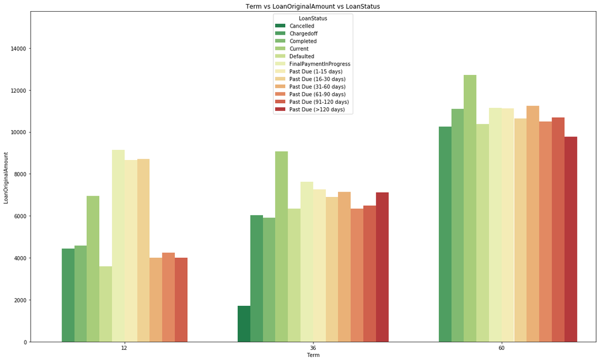